# Biostatistical Methods II Homework 8

Arghya Kannadaguli (ak5357)

2025-04-13

```r
# Read in Data
health = read_xlsx("data/HW8-HEALTH.xlsx") |>
  janitor::clean_names() |>
  mutate( # alter variable values to improve interpretability
    time = ifelse(time %in% c(1:3), (time - 1)*3, 12),
    trt = as.factor(txt),
    health = ifelse(health == "Poor", 0, 1),
    agegroup = as.factor(agegroup)) |>  # convert to months since randomization
  select(-txt) |>
  arrange(id, time)

# Convert to grouped data
health.new = groupedData(health ~ trt | id, data = health)
```

#### **Exploratory Visualization**

The following figure shows how the proportion of good health self-reports appears to change over time for the intervention group, but not as much for the control group, suggesting a possible interaction between treatment group and time.

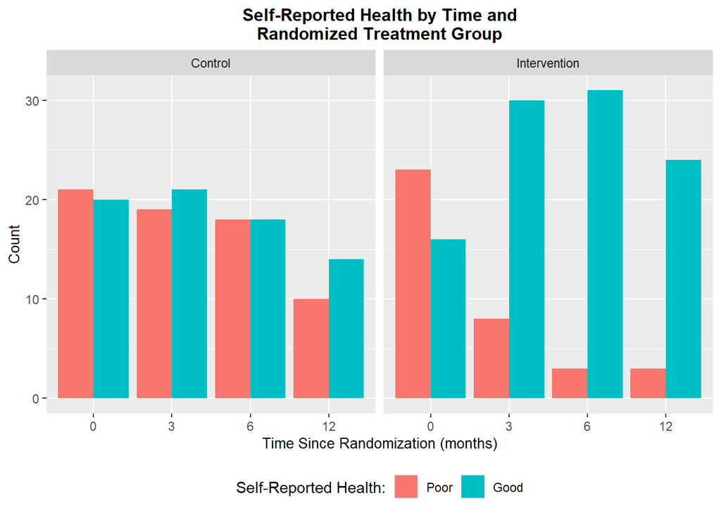

```r
health |>
  mutate(
    health = factor(health, labels = c("Poor", "Good")),
    time = as.factor(time)) |>
  ggplot(aes(x = time, fill = health, group = health)) +
  geom_bar(position = "dodge") +
  facet_grid(~ trt) +
  labs(
    title = "Self-Reported Health by Time and\nRandomized Treatment Group",
    x = "Time Since Randomization (months)",
    y = "Count",
    fill = "Self-Reported Health:"
  ) +
  theme(
    plot.title = element_text(face = "bold", hjust = 0.5, size = 12),
    plot.subtitle = element_text(face = "italic", hjust = 0.5, size = 10),
    plot.caption = element_text(hjust = 0.5),
    axis.title = element_text(size = 10),
    legend.position = "bottom"
  )
```

**Problem:** Fit a generalized linear mixed effects model with subject-specific random intercepts. Interpret your estimates. How are the interpretations different from the GEE model?

#### **Generalized Linear Mixed Effects Model (GLMER)**

We are generating the following model. Since the outcome variable is binary, this will be a logistic regression model. *Note: The agegroup terms only have the subscript for $i$ because each individual’s agegroup does not change throughout the dataset.*

$$\begin{align*}
logit(Pr(Y_{ij} = 1)) &= \beta_0 + \alpha_i + \beta_1 \cdot
(\text{agegroup25-34})_i + \beta_2 \cdot (\text{agegroup35+})_i +
\beta_3 \cdot \text{trtIntervention}\\
&\quad + \beta_4 \cdot \text{time}_{ij} +
\beta_5 \cdot (\text{trtIntervention} \cdot \text{time}) + \epsilon_{ij}
\end{align*}$$
where:

- $Y_{ij}$ = binary outcome of self-reported health (0 = Poor, 1 = Good) for $i$th participant’s $j$th observation
- $logit(p)$ = $log\left(\frac{p}{1-p}\right)$ link function for probability of $Y_{ij} = 1$ (or `health` = Good)
- $\beta_0$ = fixed intercept
- $\alpha_i$ = random intercept for $i$th individual
- $\beta_1$ = fixed coefficient for agegroup = 25-34 (reference category agegroup = 15-24)
- $\beta_2$ = fixed coefficient for agegroup = 35+ (reference category agegroup = 15-24)
- $\beta_3$ = fixed coefficient for treatment group trt = Intervention (reference category trt = Control)
- $\beta_4$ = fixed coefficient for time (months) passed since randomization
- $\beta_4$ = fixed coefficient for interaction between treatment and time (months) passed since randomization

**Fitting the model**

I chose to include the interaction term between treatment and time due to the results of the Likelihood Ratio Test performed below.

Model with no interaction.

```r
# Generate linear mixed effects fit
fit.glmer = glmer(health ~ agegroup + trt + time + (1 | id),
              data = health.new,
              family = binomial)

# Output model summary
summary(fit.glmer)
```

```
## Generalized linear mixed model fit by maximum likelihood (Laplace
##   Approximation) [glmerMod]
##  Family: binomial  ( logit )
## Formula: health ~ agegroup + trt + time + (1 | id)
##    Data: health.new
##
##      AIC      BIC   logLik deviance df.resid
##    326.8    348.6   -157.4    314.8      273
##
## Scaled residuals:
##     Min      1Q  Median      3Q     Max
## -2.6825 -0.5308  0.3155  0.5298  2.1969
##
## Random effects:
##  Groups Name        Variance Std.Dev.
##  id     (Intercept) 2.457    1.568
## Number of obs: 279, groups:  id, 80
##
## Fixed effects:
##                 Estimate Std. Error z value Pr(>|z|)
## (Intercept)     -0.88246    0.45409  -1.943  0.05197 .
## agegroup25-34    0.77015    0.51451   1.497  0.13442
## agegroup35+      0.34104    0.84736   0.402  0.68734
## trtIntervention  1.22358    0.49138   2.490  0.01277 *
## time             0.14399    0.04308   3.343  0.00083 ***
## ---
## Signif. codes:  0 '***' 0.001 '**' 0.01 '*' 0.05 '.' 0.1 ' ' 1
##
## Correlation of Fixed Effects:
##             (Intr) a25-34 agg35+ trtInt
## agegrp25-34 -0.521
## agegroup35+ -0.327  0.289
## trtIntrvntn -0.522 -0.027  0.017
## time        -0.385  0.009 -0.016  0.072
```

Model with interaction.

```r
# Generate linear mixed effects fit WITH interaction term
fit.glmer.int = glmer(health ~ agegroup + trt * time + (1 | id),
              data = health.new,
              family = binomial)

# Output model summary
summary(fit.glmer.int)
```

```
## Generalized linear mixed model fit by maximum likelihood (Laplace
##   Approximation) [glmerMod]
##  Family: binomial  ( logit )
## Formula: health ~ agegroup + trt * time + (1 | id)
##    Data: health.new
##
##      AIC      BIC   logLik deviance df.resid
##    313.5    338.9   -149.8    299.5      272
##
## Scaled residuals:
##     Min      1Q  Median      3Q     Max
## -5.9450 -0.4717  0.1950  0.5038  1.7555
##
## Random effects:
##  Groups Name        Variance Std.Dev.
##  id     (Intercept) 3.11     1.764
## Number of obs: 279, groups:  id, 80
##
## Fixed effects:
##                      Estimate Std. Error z value Pr(>|z|)
## (Intercept)          -0.34661    0.50721  -0.683 0.494378
## agegroup25-34         0.84823    0.56463   1.502 0.133027
## agegroup35+           0.31168    0.93022   0.335 0.737584
## trtIntervention      -0.06786    0.63110  -0.108 0.914367
## time                  0.01020    0.05499   0.186 0.852801
## trtIntervention:time  0.38068    0.11125   3.422 0.000622 ***
## ---
## Signif. codes:  0 '***' 0.001 '**' 0.01 '*' 0.05 '.' 0.1 ' ' 1
##
## Correlation of Fixed Effects:
##             (Intr) a25-34 agg35+ trtInt time
## agegrp25-34 -0.484
## agegroup35+ -0.322  0.288
## trtIntrvntn -0.563 -0.064  0.015
## time        -0.435 -0.054 -0.014  0.374
## trtIntrvnt:  0.209  0.064  0.000 -0.508 -0.503
```

Likelihood Ratio Test. Since the p-value is significant, we reject the null hypothesis that the simpler (no interactions) model is just as good. We conclude that the interaction term is necessary for this model.

```r
# Is the interaction term significant?
anova(fit.glmer, fit.glmer.int)
```

```
## Data: health.new
## Models:
## fit.glmer: health ~ agegroup + trt + time + (1 | id)
## fit.glmer.int: health ~ agegroup + trt * time + (1 | id)
##               npar    AIC    BIC  logLik deviance  Chisq Df Pr(>Chisq)
## fit.glmer        6 326.81 348.60 -157.41   314.81
## fit.glmer.int    7 313.53 338.95 -149.76   299.53 15.281  1  9.264e-05 ***
## ---
## Signif. codes:  0 '***' 0.001 '**' 0.01 '*' 0.05 '.' 0.1 ' ' 1
```

```r
# Then we decide to keep the model with interactions.
fit.glmer = fit.glmer.int
```

#### **Interpreting the GLMER model coefficients**

Let’s interpret the fixed coefficients first.

| Coefficient | Term | Estimate (Log Odds Ratio) | Odds Ratio |
| --- | --- | --- | --- |
| $\beta_0$ | (Intercept) | -0.35 | 0.71 |
| $\beta_1$ | agegroup25-34 | 0.85 | 2.34 |
| $\beta_2$ | agegroup35+ | 0.31 | 1.37 |
| $\beta_3$ | trtIntervention | -0.07 | 0.93 |
| $\beta_4$ | time | 0.01 | 1.01 |
| $\beta_5$ | trtIntervention $\cdot$ time | 0.38 | 1.46 |

Now let’s interpret the random intercepts.

```r
# View first 10 random intercepts
head(ranef(fit.glmer)$id, 10)
```

```
##     (Intercept)
## 102  -1.6123107
## 108  -0.7435014
## 113  -1.4100970
## 121  -1.4100970
## 124  -3.2546969
## 130  -1.4100970
## 132  -1.4100970
## 134  -1.4100970
## 135  -3.7587631
## 141  -2.1319225
```

| Coefficient | Term | Example Estimate for Subject 102 (Log Odds Ratio) | Odds Ratio |
| --- | --- | --- | --- |
| $\alpha_i$ | Random Intercept by Subject (`id`) | $\alpha_{102}$ = -1.61 | 0.2 |

**$\alpha_{102}$ (Random Intercept for Subject 102) Interpretation:** Subject 102 has 0.2 times the odds of reporting “Good” health, as compared with the average for their group, with all other terms held constant.

#### **GEE Model**

Here we are fitting a Generalized Estimation Equation (GEE) model. As compared to the GLMER model, which considers subject-specific intercepts, the GEE model is a marginal model and only considers the population-average intercepts and effects.

For comparability, I will include an interaction term between treatment group and time in this model as well.

```r
# Generate linear mixed effects fit
fit.gee = gee(health ~ agegroup + trt * time,
              id = id,
              data = health.new,
              family = binomial,
              corstr = "exchangeable")
```

```
##          (Intercept)        agegroup25-34          agegroup35+
##          -0.31750261           0.64318632           0.25163920
##      trtIntervention                 time trtIntervention:time
##           0.02925761           0.01977435           0.25663183
```

```r
# Output model summary
summary(fit.gee)
```

```
##
##  GEE:  GENERALIZED LINEAR MODELS FOR DEPENDENT DATA
##  gee S-function, version 4.13 modified 98/01/27 (1998)
##
## Model:
##  Link:                      Logit
##  Variance to Mean Relation: Binomial
##  Correlation Structure:     Exchangeable
##
## Call:
## gee(formula = health ~ agegroup + trt * time, id = id, data = health.new,
##     family = binomial, corstr = "exchangeable")
##
## Summary of Residuals:
##        Min         1Q     Median         3Q        Max
## -0.9790788 -0.4455352  0.1024447  0.3935206  0.5623321
##
##
## Coefficients:
##                          Estimate Naive S.E.    Naive z Robust S.E.   Robust z
## (Intercept)          -0.250632007 0.37031107 -0.6768148  0.33492629 -0.7483199
## agegroup25-34         0.651264257 0.42817159  1.5210357  0.36397140  1.7893281
## agegroup35+           0.080629374 0.72055050  0.1118997  0.54470872  0.1480229
## trtIntervention       0.094224414 0.45527833  0.2069600  0.40833589  0.2307522
## time                  0.005317489 0.03965322  0.1340998  0.03125564  0.1701290
## trtIntervention:time  0.273931740 0.08395058  3.2630120  0.11400734  2.4027552
##
## Estimated Scale Parameter:  1.296948
## Number of Iterations:  5
##
## Working Correlation
##           [,1]      [,2]      [,3]      [,4]
## [1,] 1.0000000 0.3495461 0.3495461 0.3495461
## [2,] 0.3495461 1.0000000 0.3495461 0.3495461
## [3,] 0.3495461 0.3495461 1.0000000 0.3495461
## [4,] 0.3495461 0.3495461 0.3495461 1.0000000
```

#### **How are the interpretations different?**

The GLMER model includes random intercepts by subject, to account for each subject’s baseline log-odds of success (self-reporting “Good” health). In this model, effects are interpreted within individuals to estimate how a change in a predictor affects the log-odds of success for a specific person.

In contrast, the GEE model is a marginal model which does not include random intercepts or effects. Its results are interpreted on average at a population level to estimate how a change in some predictor affects the average log-odds of success across the whole population.

For example, the interpretation of the significant interaction term `trtIntervention:time` would differ between the two models:

- **GLMER Model:** For a given individual, the change in log-odds of reporting good health per unit increase in time is 0.38 higher in the Intervention group as compared to the Control group, with all else held constant. The overall log-odds of reporting good health for any individual, accounting for all predictors, would also be influenced by that individual’s specific random-intercept, which represents that individual’s baseline deviation from the population average intercept.
- **GEE Model:** On average across the population, the change in log-odds of reporting good health per unit increase in time is 0.27 higher in the Intervention group as compared to the Control group, with all else held constant. This effect cannot be interpreted at the individual-level, because it does not account for individual-specific baselines in the way that GLMER does.